# Relatório de Engenharia de Features - Previsão de Demanda Clark/Lake (`s_40380`)

### Maior driver

Calendário semanal: dias úteis altos e fim de semana com queda de 74,6%.

### Efeito estrutural

Feriados reduzem demanda em cerca de 52,1% e afetam dias próximos.

### Memória temporal

Lags 7/14/28 capturam recorrência semanal (0,900, 0,884, 0,890).

### Clima

Contribui, mas com efeito médio menor que calendário + feriados + lags.

### Resultado técnico

Modelo final equilibrado, sem overfit forte, com ganho real após feature engineering.

## 1) Objetivo e escopo

Prever a demanda diária de passageiros na estação Clark/Lake (`s_40380`) com engenharia de features justificada visualmente.

(A) conjunto de visualizações justificando features, (B) lista completa das features finais, (C) previsão da base de teste em tabela final.

| base | linhas | colunas | data_min | data_max | faltantes_total |
| --- | --- | --- | --- | --- | --- |
| treino | 5.698 | 23 | 2001-01-22 | 2016-08-28 | 10 |
| teste | 13 | 22 | 2016-08-30 | 2016-09-11 | 0 |
| feriados | 11 | 3 | N/A | N/A | 0 |

## 2) Entendimento e qualidade dos dados

Checagens de duplicidade, nulos, faixas válidas e consistência lógica foram aplicadas no treino e no teste.

| checagem | resultado | evidencia |
| --- | --- | --- |
| Duplicatas de data (treino/teste) | OK | treino=0; teste=0 |
| Continuidade diária de datas | OK | faltas_treino=0; faltas_teste=0 |
| Nulos por coluna | OK | treino_total=10; teste_total=0; treino_cols=[l30_unemployment_rate=10] |
| Faixas válidas (clima e alvo) | OK | prob_fora=0; umidade_fora=0; temp_min>max=0; target_negativo=0 |
| Variáveis esportivas binárias (0/1) | OK | valores_fora_0_1=0 |
| Conflito lógico Home=1 e Away=1 no mesmo dia | Atenção | Blackhawks=0; Bulls=0; Bears=0; WhiteSox=2712; Cubs=2712 |
| Colunas WhiteSox/Cubs idênticas entre si | Atenção | WhiteSox_Away==WhiteSox_Home=True; Cubs_Away==Cubs_Home=True; WhiteSox_Home==Cubs_Home=True |

**Tratamento aplicado e usado no modelo final:** as variáveis redundantes de baseball foram tratadas na engenharia de features com consolidação em `baseball_game_flag` e remoção das colunas duplicadas (`WhiteSox_Away`, `WhiteSox_Home`, `Cubs_Away`, `Cubs_Home`) antes do treinamento. Ou seja, o modelo final foi treinado com os dados tratados.

## 3) Exploração e hipóteses

### 3.1 Hipótese 1: calendário semanal como principal driver

Este é o diagnóstico inicial mais forte para mobilidade urbana, e foi complementado por validação temporal e importância de features.

**Evidência:** média de dias úteis = **17,306**, média de fim de semana = **4,402**, queda de **74,6%**.

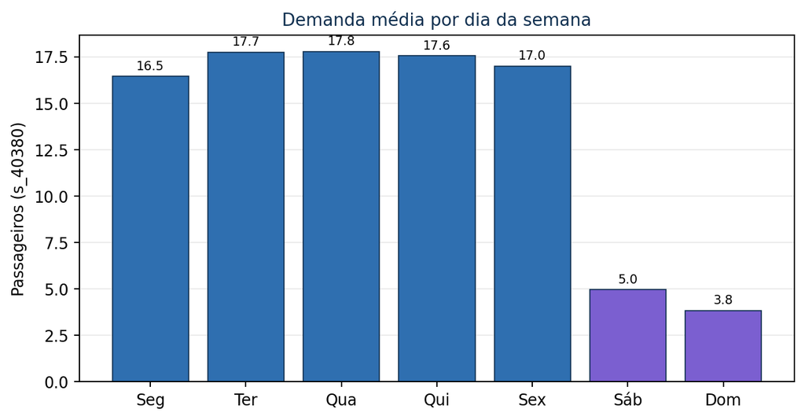

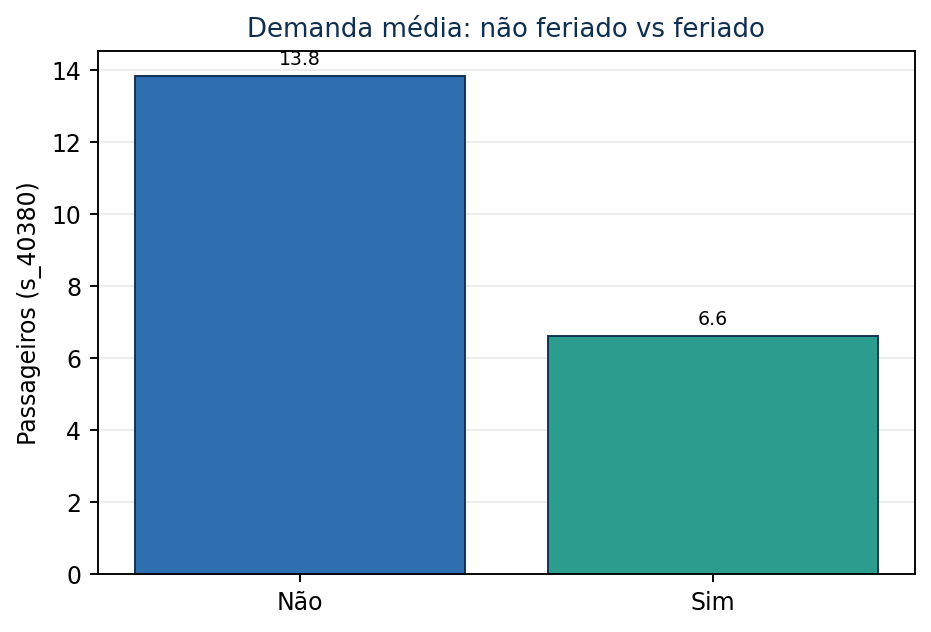

### 3.2 Hipótese 2: feriados alteram a estrutura da demanda

A queda em feriados é nítida e a proximidade do feriado também afeta o volume.

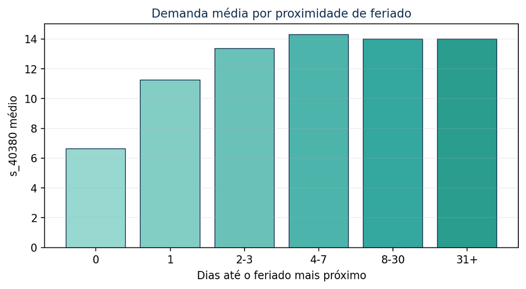

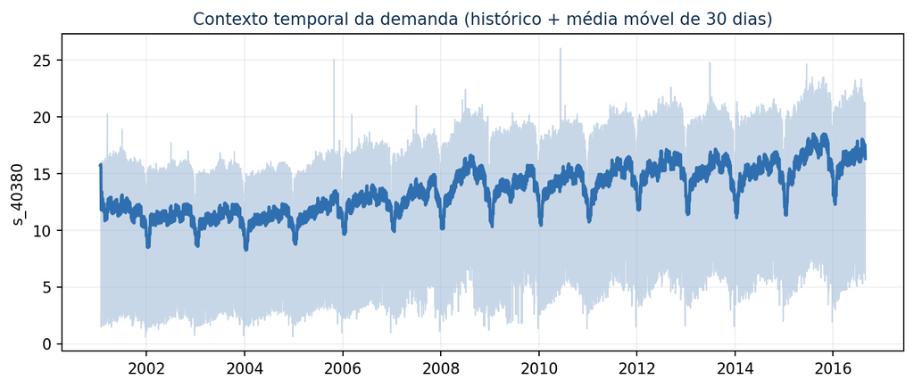

**Como interpretar o contexto temporal geral:** a linha clara mostra oscilações diárias; a linha escura (média móvel de 30 dias) mostra tendência de longo prazo. A diferença entre semana e fim de semana aparece como padrão recorrente ao longo de todo o período.

### 3.3 Hipótese 3: memória temporal (lags)

**Definição de lag:** `lag_k` é o valor da demanda observado **k dias antes**. Ex.: `lag_7` = demanda de uma semana atrás.

Como a série tem ciclo semanal, usar lags (1, 7, 14, 28) melhora a previsão de curto prazo.

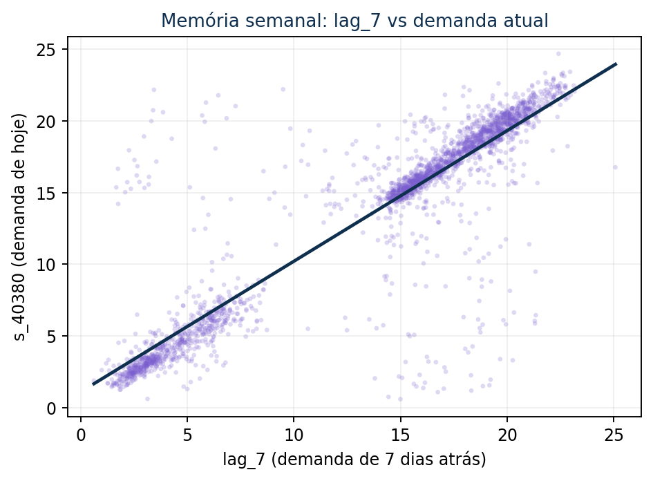

| feature | correlacao_com_target |
| --- | --- |
| s_40380 | 1,0000 |
| lag_1 | 0,4176 |
| lag_7 | 0,8998 |
| lag_14 | 0,8836 |
| lag_28 | 0,8905 |

### 3.4 Hipótese 4: clima complementa, mas não domina

A variação por faixa de temperatura existe, mas é menor que os efeitos de calendário e feriado.

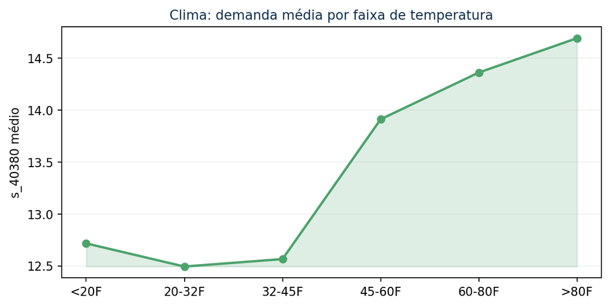

## 4) Engenharia de features

### 4.1 Grupos de features e objetivo de cada grupo

#### Calendário e sazonalidade 15 features

year, month, day, day_of_week, week_of_year, day_of_year...

#### Feriados e janelas 21 features

is_holiday_observed, is_holiday, is_holiday_fixed, is_holiday_movable, days_to_nearest_holiday, days_to_next_holiday...

#### Memória temporal 8 features

lag_1, lag_7, lag_14, lag_28, roll_mean_7, roll_std_7...

#### Clima 21 features

temp_min, temp_max, humidity, wind_max, percip_max, weather_rain...

#### Esportes e interações 12 features

sports_home_games, sports_away_games, sports_any_game, baseball_game_flag, home_game_weekend, sports_home_dow_0...

#### Economia 2 features

l14_gas_price, l30_unemployment_rate

#### Outras 7 features

Blackhawks_Away, Blackhawks_Home, Bulls_Away, Bulls_Home, Bears_Away, Bears_Home...

[output not shown]

### 4.2 Melhorias implementadas

#### Separação de feriados fixo, móvel e observado

**Definição:** Cria tipos distintos para capturar diferenças reais entre datas com regra fixa, datas móveis e dias observados.

**Racional:** Evita tratar todos os feriados como iguais, melhorando a sensibilidade do modelo a diferentes padrões de mobilidade.

**Features:** `is_holiday_fixed, is_holiday_movable, is_holiday_observed`

#### Flags de véspera e pós-feriado

**Definição:** Marca janelas direcionais antes e depois de feriados (1 e 3 dias).

**Racional:** Captura deslocamento de comportamento ao redor do feriado, não apenas no dia exato.

**Features:** `pre_holiday_1d, pre_holiday_3d, post_holiday_1d, post_holiday_3d`

#### Deltas climáticos (dia contra dia)

**Definição:** Mede variação diária de temperatura média, amplitude térmica e precipitação.

**Racional:** Mudanças bruscas de clima podem alterar demanda, mesmo quando nível absoluto do clima é parecido.

**Features:** `temp_mean_delta_1d, temp_range_delta_1d, precip_delta_1d`

#### Interações explícitas com dia da semana

**Definição:** Cria combinações de feriado×dia da semana e jogos em casa×dia da semana.

**Racional:** O mesmo evento pode ter efeito diferente em segunda, sexta ou domingo.

**Features:** `is_holiday_dow_0..6, sports_home_dow_0..6`

#### Features de regime

**Definição:** Representa cenários de clima extremo e períodos de feriado prolongado/início-fim de mês.

**Racional:** Ajuda o modelo a reagir a comportamentos de exceção que não aparecem no padrão médio.

**Features:** `temp_extreme_any, long_holiday_regime, month_boundary_weekday`

### 4.3 Lista completa das features finais (organizada por grupos)

A lista está estruturada por tema para leitura rápida, com todos os nomes disponíveis em cada bloco expansível.

**Calendário e sazonalidade (15)**

year, month, day, day_of_week, week_of_year, day_of_year, is_weekend, is_month_start, is_month_end, dow_sin, dow_cos, month_sin, month_cos, days_since_start, month_boundary_weekday

**Feriados e janelas (21)**

is_holiday_observed, is_holiday, is_holiday_fixed, is_holiday_movable, days_to_nearest_holiday, days_to_next_holiday, days_since_prev_holiday, holiday_window_1d, holiday_window_3d, pre_holiday_1d, pre_holiday_3d, post_holiday_1d, post_holiday_3d, is_holiday_dow_0, is_holiday_dow_1, is_holiday_dow_2, is_holiday_dow_3, is_holiday_dow_4, is_holiday_dow_5, is_holiday_dow_6, long_holiday_regime

**Memória temporal (8)**

lag_1, lag_7, lag_14, lag_28, roll_mean_7, roll_std_7, roll_mean_14, roll_std_14

**Clima (21)**

temp_min, temp_max, humidity, wind_max, percip_max, weather_rain, weather_snow, weather_cloud, weather_storm, temp_mean, temp_range, is_freezing_day, heavy_precip, precip_log, temp_mean_delta_1d, temp_range_delta_1d, weather_severity_index, weather_x_weekend, temp_extreme_low, temp_extreme_high, temp_extreme_any

**Esportes e interações (12)**

sports_home_games, sports_away_games, sports_any_game, baseball_game_flag, home_game_weekend, sports_home_dow_0, sports_home_dow_1, sports_home_dow_2, sports_home_dow_3, sports_home_dow_4, sports_home_dow_5, sports_home_dow_6

**Economia (2)**

l14_gas_price, l30_unemployment_rate

**Outras (7)**

Blackhawks_Away, Blackhawks_Home, Bulls_Away, Bulls_Home, Bears_Away, Bears_Home, precip_delta_1d

## 5) Modelagem, validação temporal e diagnóstico

### 5.1 Como os modelos foram usados e comparados

Foram testados `Ridge`, `RandomForest` e `HistGradientBoosting` sob o mesmo protocolo temporal (backtesting rolling com horizonte de 13 dias, simulando previsão real multi-passo). O modelo vencedor foi definido por menor RMSE, com MAE e MAPE como métricas complementares.

### 5.2 Comparação dos modelos

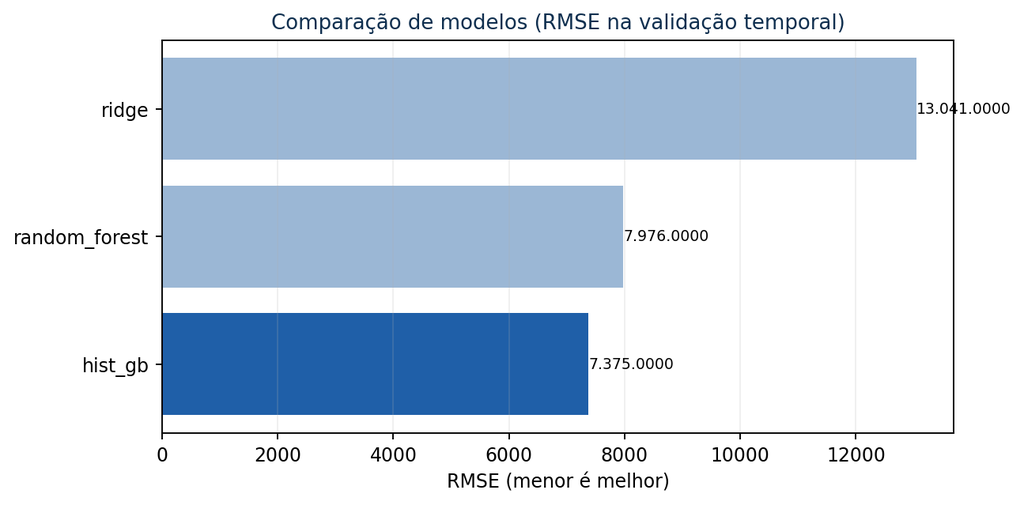

| modelo | rmse | mae | mape_percent |
| --- | --- | --- | --- |
| hist_gb | 7.375,0000 | 5.539,0000 | 47.573,0000 |
| random_forest | 7.976,0000 | 6.347,0000 | 54.191,0000 |
| ridge | 13.041,0000 | 9.895,0000 | 92.806,0000 |

### 5.3 Efeito da engenharia de features (baseline vs enhanced)

#### Efeito da engenharia de features (baseline vs enhanced)

Baseline (sem novas features) Enhanced (com novas features)

RMSE

Baseline 0,7779

Enhanced 0,7375

Melhora: -0,0404 (-5,19%)

MAE

Baseline 0,5754

Enhanced 0,5539

Melhora: -0,0215 (-3,74%)

MAPE

Baseline 4,9257%

Enhanced 4,7573%

Melhora: -0,1684 p.p. (-3,42%)

Conclusão de 5.3: ao adicionar as novas features, o erro caiu nas três métricas ao mesmo tempo, sem trade-off oculto entre RMSE, MAE e MAPE.

### 5.4 Diagnóstico de overfit/underfit

#### Diagnóstico de overfit/underfit: treino vs validação temporal

Treino Validação temporal

RMSE

Treino 0,5558

Validação 0,7375

Gap: +0,1816

MAE

Treino 0,3418

Validação 0,5539

Gap: +0,2121

MAPE

Treino 4,1762%

Validação 4,7573%

Gap: +0,5811 p.p.

Leitura: o modelo erra menos no treino do que na validação (comportamento esperado), mas sem diferença extrema. Classificação final: **ajuste equilibrado**.

Razão treino/validação (RMSE): **0,7537** (treino = 75,37% do erro de validação). Diagnóstico consolidado: **Ajuste equilibrado**.

## 6) Entregáveis

### 6.1 Entregável A: visualizações que justificam as features

As visualizações principais estão distribuídas nas seções 3 e 5 (calendário, feriado, lag, clima, comparação de modelos e diagnóstico).

### 6.2 Entregável B: lista das features finais do modelo

A lista completa e organizada por grupos está na seção 4.3.

### 6.3 Entregável C: previsão da base de teste

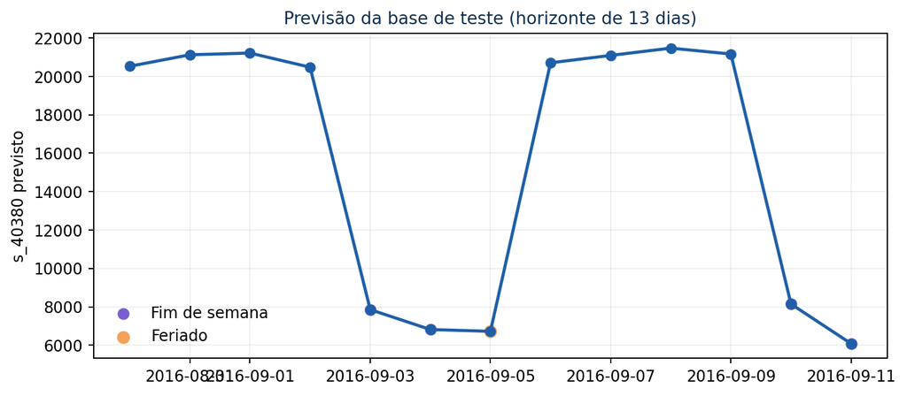

| date | day_of_week | is_weekend | is_holiday | dia_semana | s_40380_pred |
| --- | --- | --- | --- | --- | --- |
| 2016-08-30 | 1 | Não | Não | Terça | 20.530,000 |
| 2016-08-31 | 2 | Não | Não | Quarta | 21.128,000 |
| 2016-09-01 | 3 | Não | Não | Quinta | 21.217,000 |
| 2016-09-02 | 4 | Não | Não | Sexta | 20.481,000 |
| 2016-09-03 | 5 | Sim | Não | Sábado | 7.856,000 |
| 2016-09-04 | 6 | Sim | Não | Domingo | 6.818,000 |
| 2016-09-05 | 0 | Não | Sim | Segunda | 6.724,000 |
| 2016-09-06 | 1 | Não | Não | Terça | 20.710,000 |
| 2016-09-07 | 2 | Não | Não | Quarta | 21.095,000 |
| 2016-09-08 | 3 | Não | Não | Quinta | 21.474,000 |
| 2016-09-09 | 4 | Não | Não | Sexta | 21.167,000 |
| 2016-09-10 | 5 | Sim | Não | Sábado | 8.146,000 |
| 2016-09-11 | 6 | Sim | Não | Domingo | 6.083,000 |

Atualizado em 2026-03-04 • Projeto INSPER • Engenharia de Features para previsão de demanda